# t-SNE Optimization

## Perplexity Scaling

What about the tactic of starting at a high perplexity and repeatedly optimizing at lower perplexities? Below is the L-BFGS result from starting at a perplexity of 2048 (the closest power of 2 to half the dataset size) and then halving the perplexity until a perplexity of 64 is reached, followed by a final optimization at 40. I should say I made no effort to restrict the number of iterations or function or gradient evaluations (although at larger perplexities, it converges quite quickly), so this is a very slow method and hence not really practical. But this provides a sense of how good results can get:

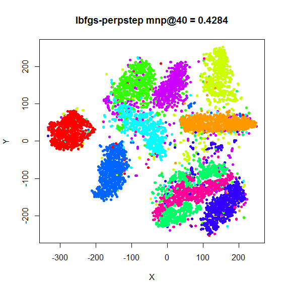

MNIST perplexity scale

That’s much better. Can this be turned into a practical optimization method, i.e. one which can be used with the same number of iterations as starting from the target perplexity? We shall have to decide how to split the number of iterations between the higher perplexity values. The strategy outlined in the NeRV paper is to carry out ten steps of conjugate gradient at (what is effectively) a higher perplexity, followed by twenty steps of conjugate gradient at the target perplexity. So that’s a 1:2 ratio. Alternatively, the multiscale JSE paper simply suggests allowing up to 200 steps of L-BFGS per perplexity value, and when comparing with t-SNE with the DBD, allowing t-SNE the same number of evaluations. If we draw a comparison between early exaggeration and perplexity scaling (which both have the goal of avoiding shallow minima), the large-scale Barnes-Hut implementations tend to allow for a longer period of early exaggeration, stopping at iteration 250, rather than iteration 100, which coincides with the point at which the momentum is increased. So that suggests the first 250 iterations out of the standard 1000 can be equated with the perplexity scaling period. Arbitrarily, we’ll choose that: for the first 250 iterations we’ll do perplexity scaling, leaving 750 for the target perplexity. As a result, for the delta-bar-delta method, we should switch the momentum earlier, too. If the lower momentum is due to the influence of early exaggeration requiring milder optimization conditions, we could start the optimization with the momentum at its high value, but to be on the safe side, in the example below, we’ll just spend fewer iterations at the lower momentum.

It’s also of interest to see if the delta-bar-delta method also benefits from stepping down from larger perplexities. Results were generated using (with `iris` as an example):

```
iris_dbd_pstep <- smallvis_perpstep(step_iter = 250, X = iris, scale = FALSE, verbose = TRUE, Y_init = "spca", ret_extra = c("DX", "DY"), perplexity = 40, eta = 100, mom_switch_iter = 185, max_iter = 1000)
iris_lbfgs_pstep <- smallvis_perpstep(step_iter = 250, X = iris, scale = FALSE, verbose = TRUE, Y_init = "spca", ret_extra = c("DX", "DY"), perplexity = 40, max_iter = 1000, opt = list("l-bfgs"))
```

Results are shown with the equivalent non-stepped version from the previous results above on the left, and the perplexity stepped version on the right.

dataset

perplexity = 40

step perplexity

iris DBD

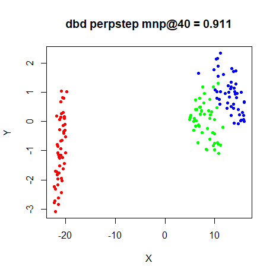

iris L-BFGS

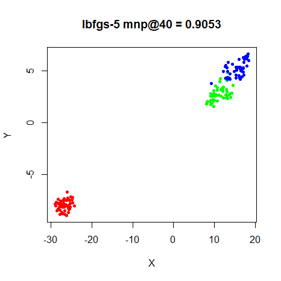

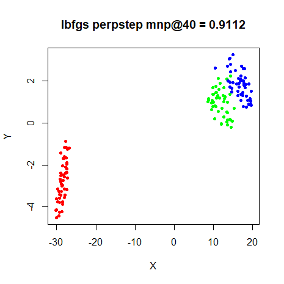

s1k DBD

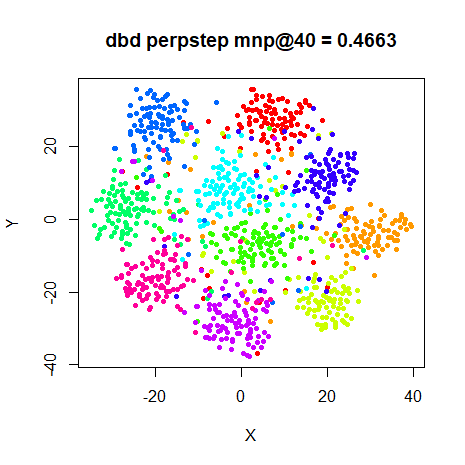

s1k LBFGS

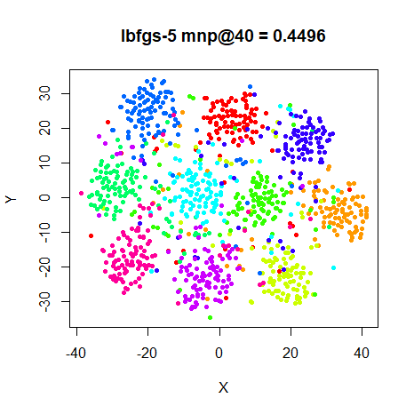

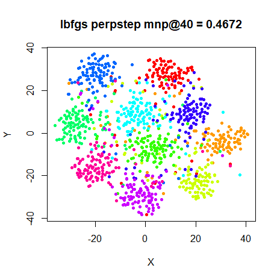

oli DBD

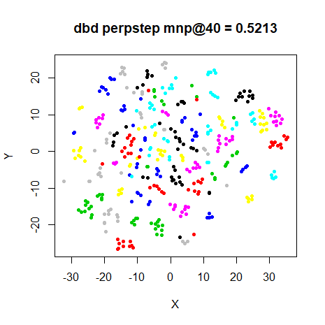

oli LBFGS

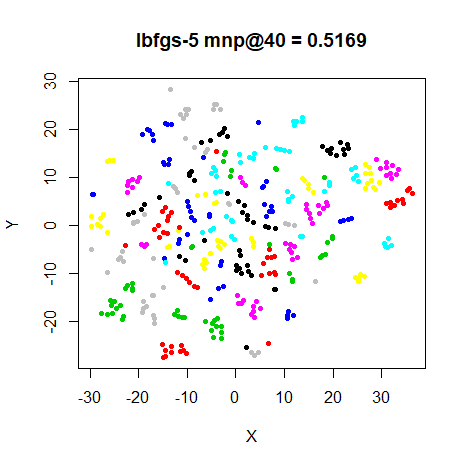

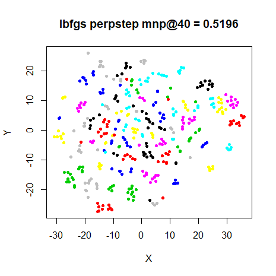

frey DBD

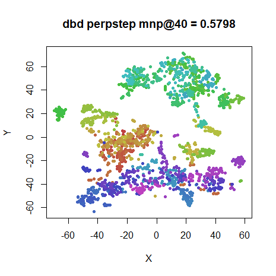

frey LBFGS

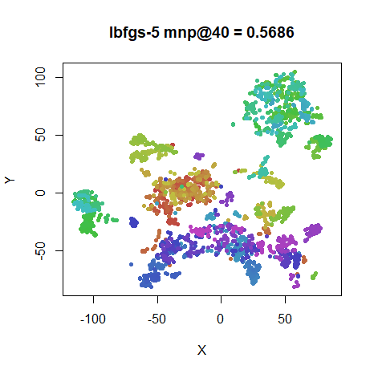

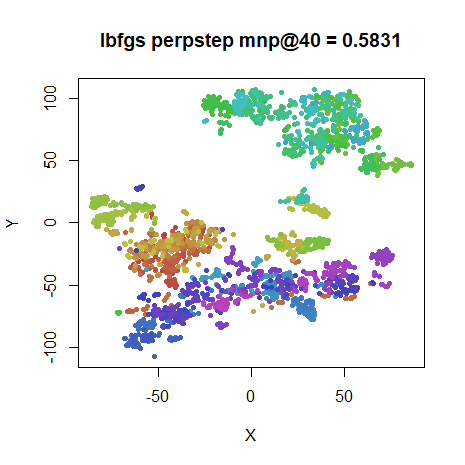

COIL-20 DBD

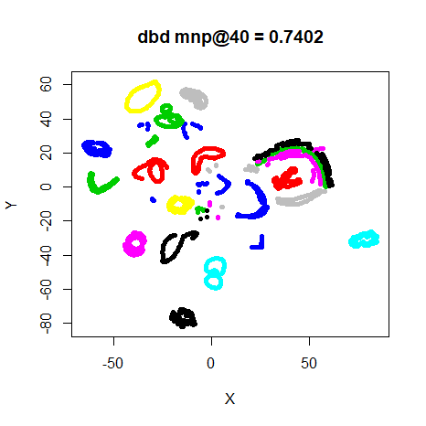

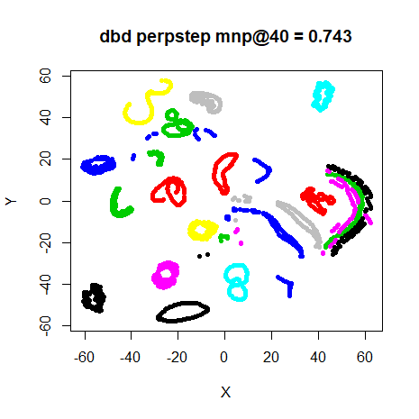

COIL-20 LBFGS

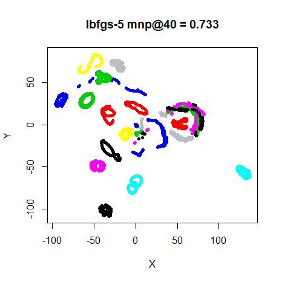

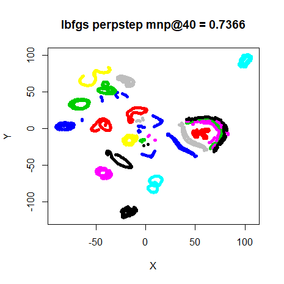

MNIST DBD

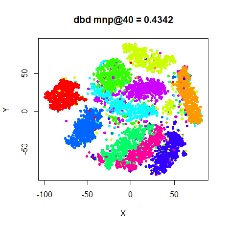

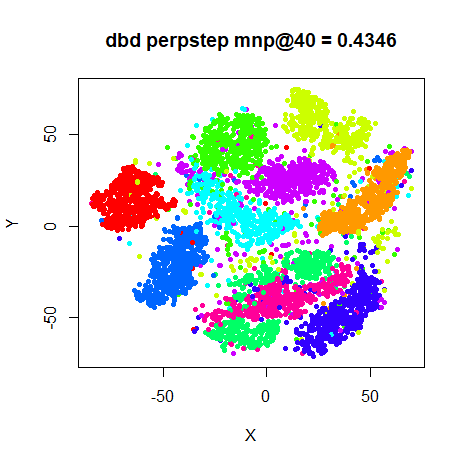

MNIST LBFGS

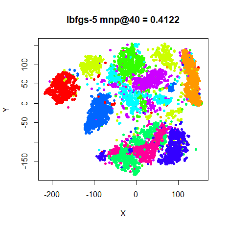

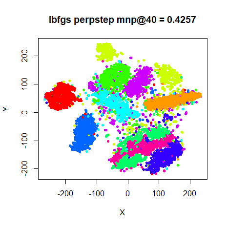

Fashion DBD

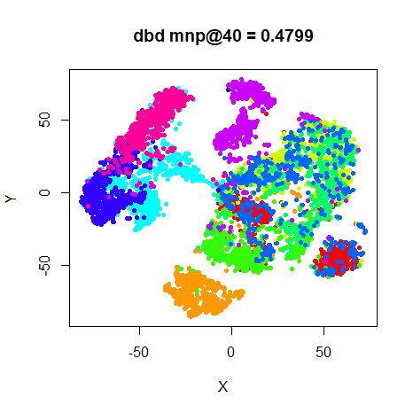

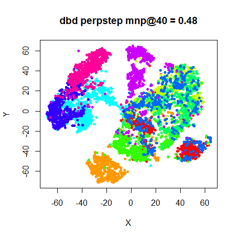

Fashion LBFGS

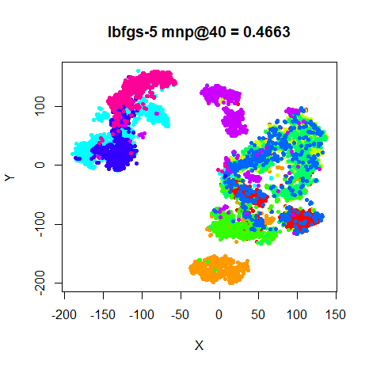

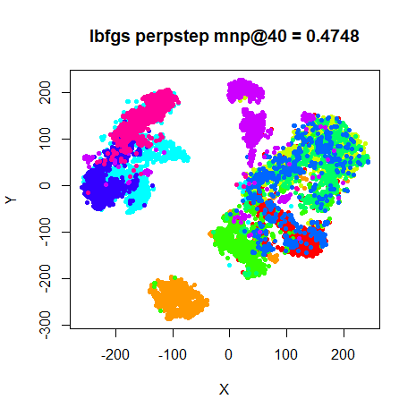

For L-BFGS, the perplexity stepping always improves the neighborhood preservation (although the difference is always small), but more importantly, the MNIST result looks a lot better. Maybe not quite as good as the result which allowed more than 1000 iterations, but it didn’t take as long.

The DBD results show a similar pattern, although the preservations don’t always improve. But the final results do look more similar to those from from the L-BFGS optimization when doing perplexity stepping, suggesting that these methods find minima which are closer to each other than without scaling.

There are two downsides of this method. The obvious one is that you have to carry out the perplexity calibration multiple times. At least as datasets grow larger this becomes a proportionally smaller part of the runtime, so it’s not like carrying out 5 perplexity calibrations requires 5 times the CPU time. A more minor issue is that the optimization starts from scratch for each perplexity. If, as the spectral direction paper suggests, L-BFGS has difficulties making progress at early iterations because of a lack of information with which to approximate the Hessian, we waste proportionally more of the iterations we have available by effectively resetting the memory of the optimizer multiple times.

Things can still go wrong. Here are two plots of the MNIST subset, both initialized from the Laplacian Eigenmap. The left hand image retains a memory of `5` vectors, the right hand version uses `50`:

memory = 5

memory = 50

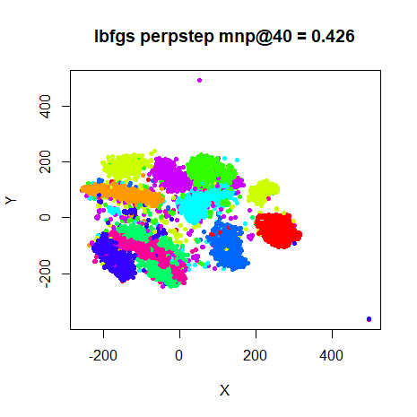

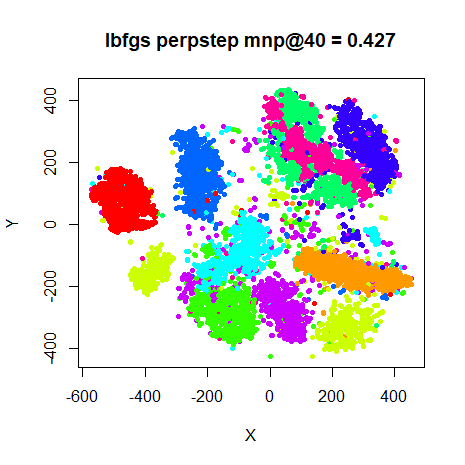

The left hand side plot shows there are a few outlying points. This is something I see quite a lot with the L-BFGS minimizations: a small number of points get pushed a long way out, and then due to the small gradient associated with long distances, take a large number of iterations to rejoin the main embedding, or as we see in this case, don’t get back at all. The right hand plot shows that upping the memory used by the minimization helps in this case, but I don’t have any reason to believe that more memory is guaranteed to work.

## Conclusions

If you want to use L-BFGS to optimize the t-SNE cost function, you should probably use the perplexity stepping method to maximize your chances of getting a good result. Of course, you can just use the standard delta-bar-delta method when it comes to t-SNE. But hopefully these findings also apply to other cost functions where DBD doesn’t work as well.

## August 16 2020: What about qSNE?

The [qSNE source is available](https://bitbucket.org/anthakki/qsne/src/master/). Based on my understanding of that, it does the following by default:

- no scaling of the input.
- a perplexity of 30 is used.
- initialization via PCA, then rescaling to standard deviation of 1. You can provide your own input via (`-i`).
- no early exaggeration.
- L-BFGS uses the ten previous iterates/gradients for its memory. This can be modified with the `-m` option.
- the line search is a simple Armijo backtracking search, with the constant in the Armijo condition test being `c1 = 0.5`, starting at $\alpha = 1$ at each iteration, and halving $\alpha$ during backtracking. The value of `c1` can be adjusted via the `-L` option.
- a check on the relative error of the cost is applied at every iteration, with a tolerance of 1e-4 (adjustable via the `-t` option). Because the backtracking search requires evaluating the cost, there’s no extra computational expense to doing a tolerance check every iteration. To avoid premature convergence, the tolerance check is not applied for the first 15 iterations.
- if you set “compatibility mode” (`-C`), you get the usual delta-bar-delta optimization used in Rtsne, along with early exaggeration and the input is scaled. However, the initialization doesn’t change.

With mize installed, you can get something close to the qSNE defaults using:

```r
iris_qsne <- smallvis(iris, Y_init = "pca", Y_init_sdev = 1,
           opt = list("l-bfgs", line_search = "backtracking", c1 = 0.5,
                    memory = memory, try_newton_step = TRUE,
                    step_next_init = 1, step_down = 0.5),
           epoch = 1, tol = 1e-4, tol_wait = 15, scale = FALSE,
           perplexity = 30)
```

qSNE optimization is much faster than smallvis for the datasets considered here because although it does not use any approximations, its implementation is multi-threaded. However, the PCA-based initialization is not very efficient for high-dimensional datasets: on my machine, `oli` with 4 096 features, took nearly two minutes to complete, and `coil20` with 16 384 features, took nearly two hours. To avoid spending time generating the PCA initializations multiple times, for all the results below, I generated the PCA input for both `qsne` and `smallvis` using a separate run of `smallvis` with 0 iterations (`Y_init = "pca", Y_init_sdev = 1, max_iter = 0`) and exporting the `smallvis` results to a TSV file which can be used as input to `qsne` with the `-i` option. To make sure there was no major differences between how `smallvis` generated PCA-based initialization and the internal `qsne` initialization, I checked the output of `qsne` with `mnist6k` and `fashion6k` using both methods. Coordinates were identical in both cases.

In the results below, the images for each dataset are as follows:

- top left: `qsne` with default settings.
- top right: `qsne` with `-t0` to force 1000 iterations. This is to account for the possibility that the default tolerance is too lenient for these datasets, and we might see better visualizations with a longer optimization.
- bottom left: `qsne` with `-C` to use the traditional delta-bar-delta optimization, called `GDM` in the title which is how the `qsne` source code refers to it.
- bottom right: `smallvis` attempting to provide an optimization as close to that of default `qsne` as possible.

The number of iterations and the cost are given for all images. For the `smallvis` results only, the time taken, and counts of the function (`fn`) and gradient (`gr`) evaluations are also provided.

### iris

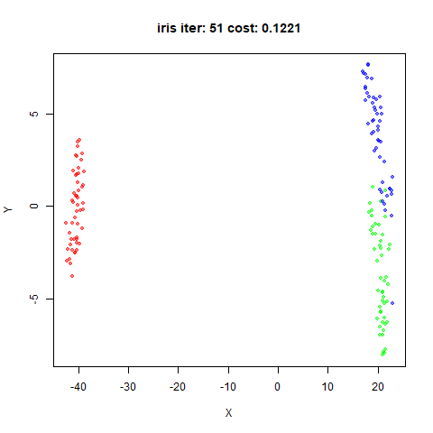

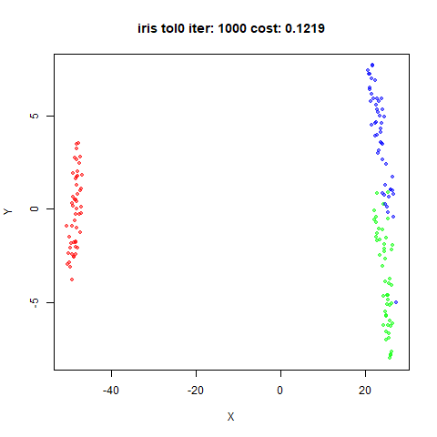

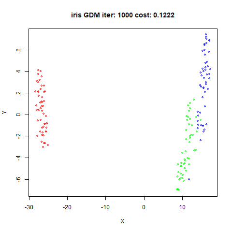

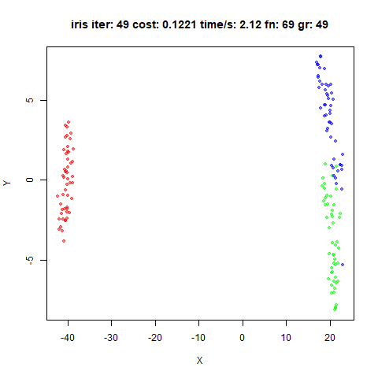

### s1k

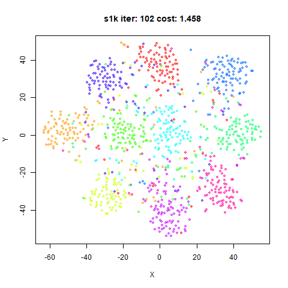

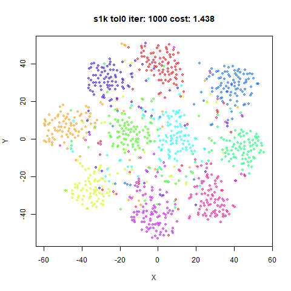

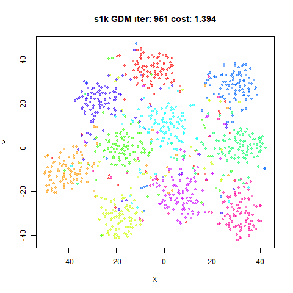

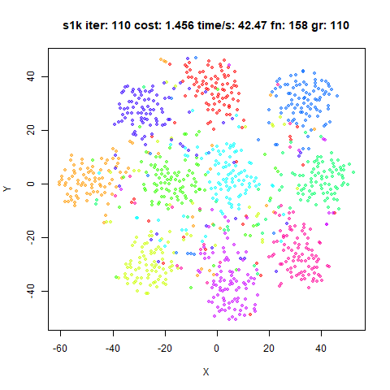

### oli

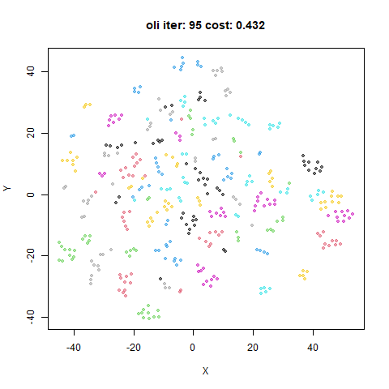

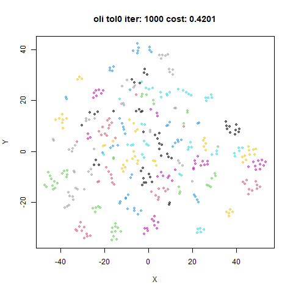

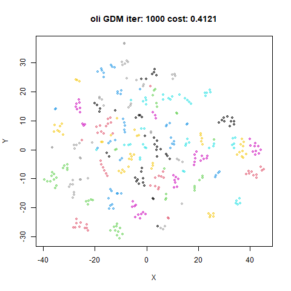

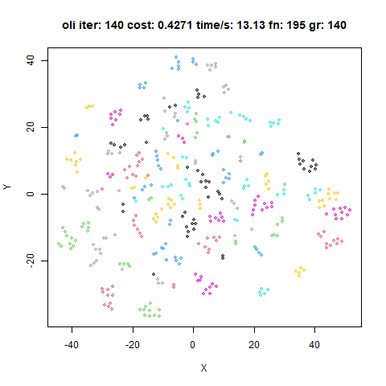

### frey

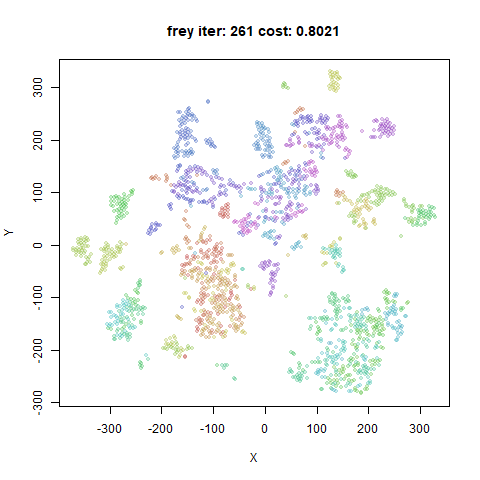

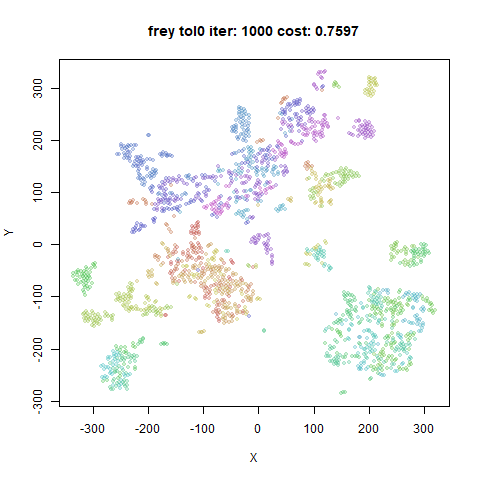

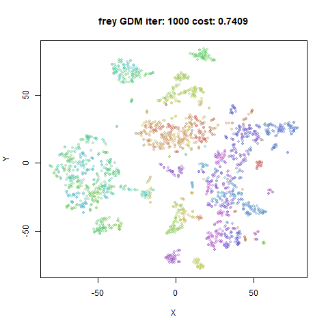

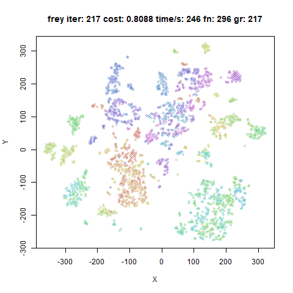

### coil20

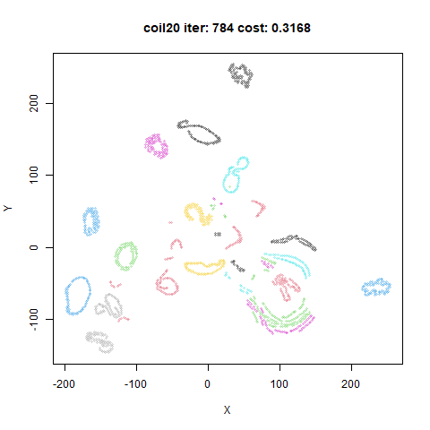

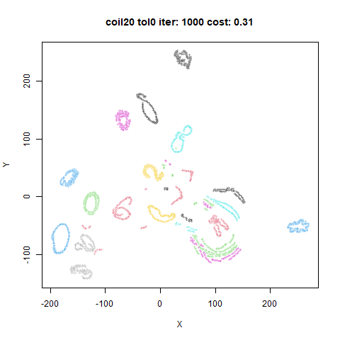

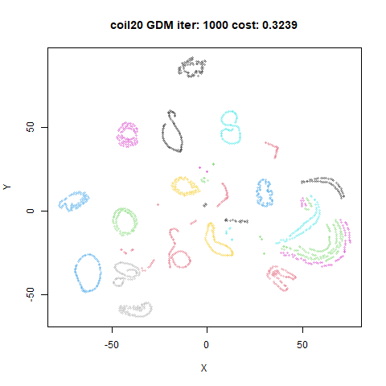

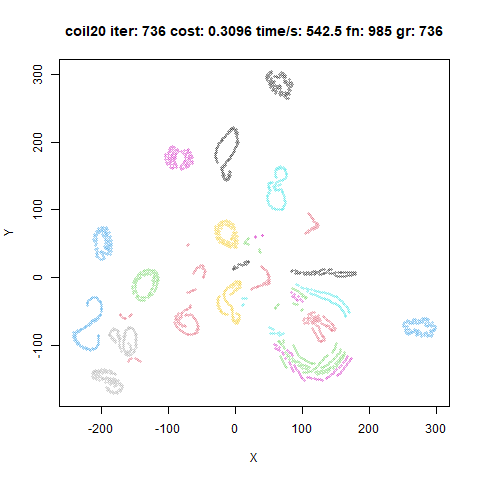

### mnist6k

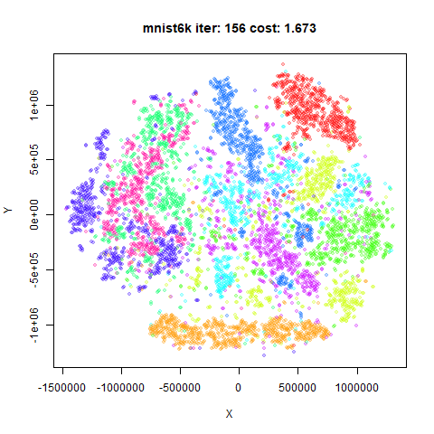

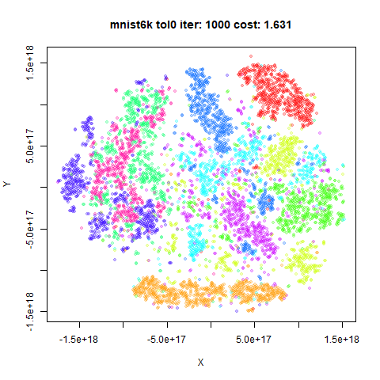

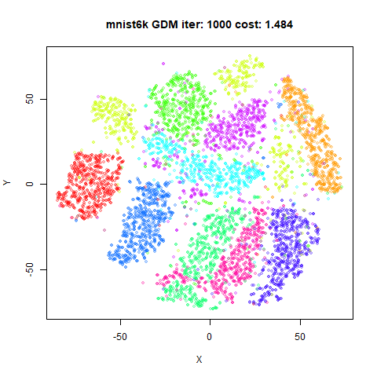

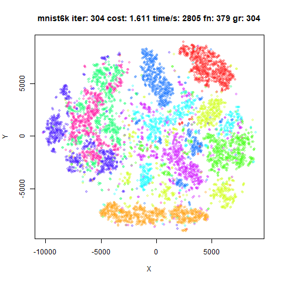

### fashion6k

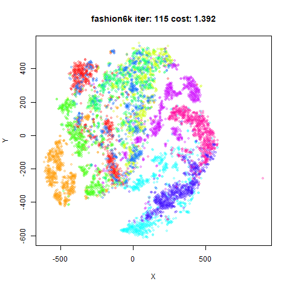

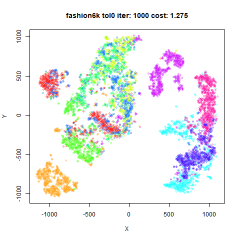

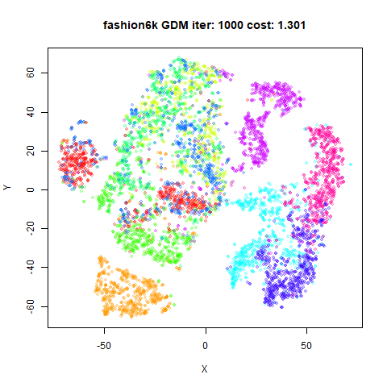

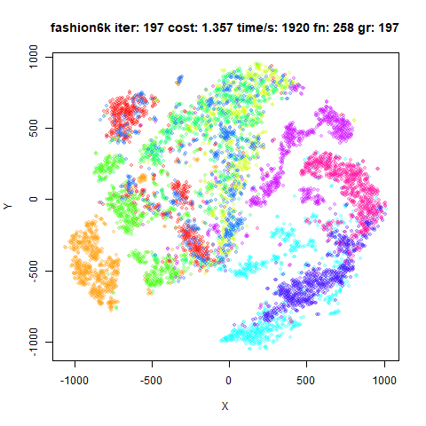

Results are very similar between `smallvis` (bottom right) and `qsne` (top left): they converge at a similar iteration, the cost values at convergence are similar, and visually the results look similar. Unfortunately, the results don’t look that great: they have all the problems mentioned above, particularly for `mnist6k` and `fashion6k`.

The `fashion6k` result in particular has an outlier point. Could it just be that the tolerance is too loose for these datasets? Not really. `fashion6k` does clean up if it’s allowed to run for longer, but the other datasets don’t do much, i.e. they are pretty well optimized for visualization purposes. For `mnist6k` making it optimize for longer has little effect on the result visually, but the distances between points has now increased hugely. Running the L-BFGS results for longer number of iterations removes most of its appeal for t-SNE anyway.

Could it be that the initial coordinates aren’t great? Probably not. The compatibility results (bottom left) use slightly different scaling of the input data and early exaggeration, and find results which look pretty much the same, except a *much* better result for `mnist6k` is also obtained.

For `iris` and `mnist6k`, I looked at using the more typical standard deviation for the initialized coordinates, i.e. `1e-4` instead of `1`, again by exporting PCA results from `smallvis`. In both cases, `qsne` was unable to make any progress at all, and the optimization terminates after 15 iterations with the cost function unchanged. With the compatibility options set, optimization proceeded almost identically as when the coordinates were initialized with a standard devation of 1.

Finally, does the use of the Armijo line search cause issues for L-BFGS, when a full Wolfe line search is usually recommended? I experimented with modifying the `qsne`-like settings in `smallvis` to use a Wolfe line search. For every dataset, on the first iteration, a very large value of $\alpha$ is chosen (greater than ten), but subsequent iterations are always 1 or smaller. Restricting the maximum value of $\alpha$ to 1-10 doesn’t have much effect on the results and they aren’t noticeably different (or better) than those that use the Armijo line search. However, whe using a Wolfe line search, the coordinates were able to be initialized from the smaller standard deviation coordinates, and you can use early exaggeration, although in that case you need to allow the maximum $\alpha$ to be as large as it wants, as otherwise the optimization seems unable to adapt when the exaggeration is turned off.

The `qsne` results independently confirm my own findings with L-BFGS: you *might* be able to get a result more quickly than using delta-bar-delta, but it’s not necessarily a huge time saving and based on my experience with `mnist6k` in particular, the results can be mediocre, to put it mildly.

If for some reason Barnes-Hut t-SNE or FIt-SNE doesn’t work for your needs and you are looking for fast non-approximate t-SNE results, then `qsne` seems to be a good choice. However, based on these results, I wouldn’t use the L-BFGS optimizer and would recommend sticking with the “compatibility” mode, i.e. use the `-C` option. I would also be wary of using the qSNE default initialization, especially if you have high-dimensional data.

Up: [Documentation Home](https://jlmelville.github.io/smallvis/).